# Introduction to GLM

This tutorial to generalized linear mixed modeling is based in the fantastic book entitled **A beginner´s guide to GLM and GLMM with R - a frequentist and Bayesian perspective for the ecologist** by Alain F. Zuur, Joseph M. Hilbe and Elena N. Leno and published by Highland Statistics Ltd in 2013. Our aim is to re-analysed the data using the `tidyverse` package to manipulate and plot the data and the packages `glmmTMB` and `RStan` for frequentist and Bayesian analyses respectively. Databases can be downloaded from http://highstat.com/index.php/beginner-s-guide-to-glm-and-glmm. I should stress that I am not an ecologist, I am just and sport scientist with a passion for the R universe and the statistical modeling.

In the first chapter they investigate the relationship between total fish abundance and mean depth for different time periods (fist time period, 1979 - 1989; second time period, 1997 - 2002). We plot the data before applying any model.

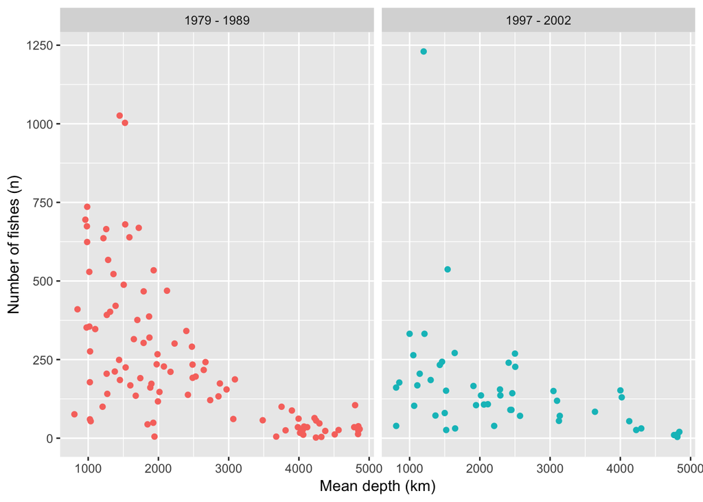

```r
library(readxl)
library(tidyverse)

# Note that I have stored all databases in a folder called "Databases"
# Read database
Fish_db <- read_xls(path = "Databases/Baileyetal2008.xls")

# Figure 1.1
Fish_db %>%
  ggplot(aes(x = MeanDepth, y = TotAbund, color = factor(Period))) +
  geom_point() +
  ylab("Number of fishes (n)") +
  xlab("Mean depth (km)") +
  theme(legend.position = "none") +
  facet_wrap(~ Period, labeller = labeller(Period = c("1" = "1979 - 1989", "2" = "1997 - 2002")))
```

## Poisson GLM

Any GLM is specified in three steps:

1. A distribution for the response variable
2. A predictor function specyfying the covariates
3. The link function between the predictor function and the mean of the distribution

#### 1. Distribution function

For count data two commonly distributions are the Poisson and the negative binomial. The Poisson distribution function is given by:

$$\normalsize
\begin{aligned}
f(Y|\mu) = Pr(Y = y|\mu) = \frac{\mu^y · e^{-\mu}}{y!}
\end{aligned}$$

Where the notation $f(Y|\mu)$ represents the Poisson distribution of a variable $Y$ for given mean $\mu$.

#### 2. Predictor function

Merely specifies the covariates that wil be used in the model. In our case:

$$\normalsize
\begin{aligned}
\eta_i = \beta_1 + \beta_2 · MeanDepth_i
\end{aligned}$$
Where $\beta_1$ and $\beta_2$ are the parameters of the model.

#### 3. Link the mean of the distribution and the predictor function

In this example Total abundance (i.e. the outcome variable) is assumed that is Poisson distributed with mean $\mu_i$, Hence:

$$\normalsize
\begin{aligned}
TotAbund_i \sim P(\mu_i)
\end{aligned}$$

$$\normalsize
\begin{aligned}
E(TotAbund_i) = var(TotAbund_i) = \mu_i
\end{aligned}$$
$$\normalsize
\begin{aligned}
\eta_i = \beta_1 + \beta_2 · MeanDepth_i
\end{aligned}$$
The canonical link function for the Poisson distribution is the **log** link function, which is defined by:

$$\normalsize
\begin{aligned}
log(\mu_i) = \eta_i \Leftarrow\Rightarrow \mu_i = e^{\eta_i}=e^{\beta_1 + \beta_2 · MeanDepth_i}
\end{aligned}$$
The log link implies that the fitted values are always positive regardless the values of the covariates and the estimated regression parameters.